# final_report_slides_bl

## When to put What products on promotion at What price?

### -- An exploration and modeling for a retailer's sales data

Li Dong, May 11, 2018

In this report, we are very fortunate to get ahold of the sales data from one of the largest retailers whose annual sales amounts to over 100 billion dollars. From the sales data, we aim to evaluate the impact of a sales event by modeling the sales lift through exploratory data analysis as well as statistical modelling. In the following, there are three sections. We start with the exploratory data analysis, then construct a few models, such as generalized linear model and gradient boosting tree models. Different statistical distributions for sales data are inspected, including Gamma, Poisson and Tweedie distributions. This report ends with a summary to compare these models.

- Exploratory Data Analysis
- Modeling
- Summary

*This report on purpose anonymizes the company's name, its competitors' names and the products' names in the data.*

### Exploratory Data Analysis

#### Data cleaning

```python
import numpy as np, matplotlib.pyplot as plt, seaborn as sns
import pandas as pd
import sys
import itertools
import datetime

import warnings
warnings.filterwarnings('ignore')

data_sales = pd.read_csv('sales.csv')
data_competitor = pd.read_csv('competitor_prices.csv')
```

```python
print('data_sales.head()')
data_sales.head()
```

```
data_sales.head()
```

|  | id | history_date | item_id | price | inventory | sales | promo_start_date | promo_end_date | category_id |
| --- | --- | --- | --- | --- | --- | --- | --- | --- | --- |
| 0 | 55 | 2014-01-01 | 394882669 | 0.00 | 0.0 | NaN | NaN | NaN | 3 |
| 1 | 103 | 2014-01-01 | 394908219 | 24.97 | 374.0 | NaN | NaN | NaN | 3 |
| 2 | 223 | 2014-01-01 | 394942631 | 106.33 | 374.0 | NaN | NaN | NaN | 3 |
| 3 | 319 | 2014-01-01 | 511895631 | 31.98 | 374.0 | NaN | NaN | NaN | 3 |
| 4 | 427 | 2014-01-01 | 512317778 | 33.21 | 102.0 | NaN | NaN | NaN | 3 |

```python
print('data_sales.shape')
data_sales.shape
```

```
data_sales.shape
```

```
(417407, 9)
```

```python
print('data_sales[\'item_id\'].unique().shape')
data_sales['item_id'].unique().shape
```

```
data_sales['item_id'].unique().shape
```

```
(610,)
```

```python
print('data_competitor.head()')
data_competitor.head()
```

```
data_competitor.head()
```

|  | id | history_date | item_id | competitor_id | competitor_price |
| --- | --- | --- | --- | --- | --- |
| 0 | 368 | 2016-01-18 | 394956441 | 83971 | 1581 |
| 1 | 440 | 2016-01-18 | 395384129 | 2433 | 4032 |
| 2 | 452 | 2016-01-18 | 395384129 | 2544 | 3371 |
| 3 | 464 | 2016-01-18 | 395384129 | 14484 | 3198 |
| 4 | 476 | 2016-01-18 | 395384129 | 83971 | 3310 |

```python
print('data_competitor.shape')
data_competitor.shape
```

```
data_competitor.shape
```

```
(363728, 5)
```

```python
print('data_competitor[\'item_id\'].unique().shape')
data_competitor['item_id'].unique().shape
```

```
data_competitor['item_id'].unique().shape
```

```
(513,)
```

```python
print('data_competitor[\'competitor_id\'].unique().shape')
data_competitor['competitor_id'].unique().shape
```

```
data_competitor['competitor_id'].unique().shape
```

```
(80,)
```

```python
data_sales['history_date'] = pd.to_datetime(data_sales['history_date'])
data_competitor['history_date'] = pd.to_datetime(data_competitor['history_date'])
data_sales['promo_start_date'] = pd.to_datetime(data_sales['promo_start_date'])
data_sales['promo_end_date'] = pd.to_datetime(data_sales['promo_end_date'])
```

```python
print('data_sales.history_date.min(), data_sales.history_date.max()')
data_sales.history_date.min(), data_sales.history_date.max()
```

```
data_sales.history_date.min(), data_sales.history_date.max()
```

```
(Timestamp('2014-01-01 00:00:00'), Timestamp('2017-12-06 00:00:00'))
```

Train: 2014-01-06 ~ 2016-12-25

Test : 2016-12-28 ~ 2017-01-29

```python
# remove data after 2017-1-29 and before 2014-1-6
data_sales = data_sales[(data_sales['history_date']<=datetime.datetime(year=2017,month=1,day=29)) & (data_sales['history_date']>=datetime.datetime(year=2014,month=1,day=6))]
data_competitor = data_competitor[(data_competitor['history_date']<=datetime.datetime(year=2017,month=1,day=29)) & (data_competitor['history_date']>=datetime.datetime(year=2014,month=1,day=6))]

# get training data
# remove data after 2017-12-25, since we deal with weekly data later, although 2017/12/26-27 don't have promotions, they're still included into the promotional week
data_sales_train = data_sales[(data_sales['history_date']<datetime.datetime(year=2016,month=12,day=25))]
```

```python
data_sales.shape, data_sales_train.shape, data_competitor.shape
```

```
((370375, 9), (364051, 9), (158970, 5))
```

In the following, we are going to clean data_sales and data_sales_train. Test data will be separated from data_sales at the end of the cleaning stage. We process the data separtely to prevent target leaking.

We process daily features first.

Apart from the features mentioned in the problem statement, we create some more.

- weekly_dummy: similar as monthly dummy.
- price_self_mean: overall mean price of a product, denominator for self_price_index.
- sales_self_mean: overall mean sales of a product.
- price_competitor_min: simply the denominator for competitor_price_index.
- price_competitor_min_id: as the feature name indicates.
- price_competitor_weekly_min: the min competitor price offered in the same week.
- price_competitor_weekly_min_id: as the feature name indicates.
- competitor_price_weekly_index: similar to competitor_price_index, but the denominator changes to price_competitor_weekly_min.

We note that quite a few features are later found out to be correlated with others. Those will be removed before training.

```python
def featET_daily(data_sales):
    data_sales['sales'].fillna(value=0., inplace=True)

    num_week = round((data_sales.history_date.max()-data_sales.history_date.min()).days/7)
    data_sales.loc[:, 'weekly_dummy'] = data_sales['history_date'].map(lambda t: t.week+(t.year-2014)*52 if t.week+(t.year-2014)*52<=num_week else t.week+(t.year-1-2014)*52 )
    data_competitor.loc[:, 'weekly_dummy'] = data_competitor['history_date'].map(lambda t: t.week+(t.year-2014)*52)
    data_sales.loc[:, 'monthly_dummy'] = data_sales['history_date'].map(lambda t: t.month+(t.year-2014)*12)
    data_sales.loc[:, 'promotion_indicator'] =  (data_sales['history_date'] >= data_sales['promo_start_date']) & (data_sales['history_date'] <= data_sales['promo_end_date'])

    data_sales.loc[:, 'price_self_mean'] = 0.
    data_sales.loc[:, 'sales_self_mean'] = 0.
    data_sales.loc[:, 'price_competitor_min'] = 0.
    data_sales.loc[:, 'price_competitor_min_id'] = 0
    data_sales.loc[:, 'price_competitor_weekly_min'] = 0.
    data_sales.loc[:, 'price_competitor_weekly_min_id'] = 0
    data_sales.loc[:, 'self_price_index'] = 0.
    data_sales.loc[:, 'competitor_price_index'] = 0.
    data_sales.loc[:, 'competitor_price_weekly_index'] =  0.

    products = data_sales['item_id'].unique()
    for i in products:
        ind_sales = data_sales['item_id']==i
        ind_competitor = data_competitor['item_id']==i

        idata_sales = data_sales.loc[ind_sales, :]
        idata_competitor = data_competitor.loc[ind_competitor, :]
        idata_competitor.loc[:,'competitor_price'] =  idata_competitor['competitor_price']/100.
        idata = idata_sales.merge(idata_competitor, how='left', on='item_id', suffixes=('_sales','_competitor') )
        # sort and impute with forward fill using last known value
        idata.sort_values(by=['item_id','history_date_sales'], inplace=True)
        # check if the missing values in the competitor data are in the same row
        if (idata['competitor_id'].isnull() & idata['competitor_price'].isnull() & idata['history_date_competitor'].isnull()).sum() != idata['competitor_price'].isnull().sum():
            print('NaN values appear not at the same row for competitor_id, competitor_price and history_date_competitor, so we can\'t impute them with last known value together.')
            sys.exit(0)
        idata.loc[:, 'history_date_competitor':'competitor_price'].fillna(method='ffill', inplace=True)

        i_price_mean = idata_sales['price'].mean()
        i_sales_mean = idata_sales['sales'].mean()
        data_sales.loc[ind_sales, 'price_self_mean'] = i_price_mean
        data_sales.loc[ind_sales, 'sales_self_mean'] = i_sales_mean
        idata_sales.loc[:, 'self_price_index'] = idata_sales['price'] / i_price_mean

        flag_same_day = idata['history_date_sales']==idata['history_date_competitor']
        ind_same_day_min = idata.loc[flag_same_day, 'competitor_price'].idxmin(axis=1) if flag_same_day.sum() else np.nan
        flag_same_week = idata['weekly_dummy_sales']==idata['weekly_dummy_competitor']
        ind_same_week_min = idata.loc[flag_same_week, 'competitor_price'].idxmin(axis=1) if flag_same_week.sum() else np.nan
        data_sales.loc[ind_sales, 'price_competitor_min'] = idata.loc[flag_same_day, 'competitor_price'][ind_same_day_min] if flag_same_day.sum() else np.nan
        data_sales.loc[ind_sales, 'price_competitor_min_id'] = idata.loc[flag_same_day, 'competitor_id'][ind_same_day_min] if flag_same_day.sum() else np.nan
        data_sales.loc[ind_sales, 'price_competitor_weekly_min'] = idata.loc[flag_same_week, 'competitor_price'][ind_same_week_min] if flag_same_week.sum() else np.nan
        data_sales.loc[ind_sales, 'price_competitor_weekly_min_id'] = idata.loc[flag_same_week, 'competitor_id'][ind_same_week_min] if flag_same_week.sum() else np.nan

    data_sales.loc[:, 'self_price_index'] = data_sales['price'] / data_sales['price_self_mean']
    data_sales.loc[:, 'competitor_price_index'] =  data_sales['price'] / data_sales['price_competitor_min']
    data_sales.loc[:, 'competitor_price_index'].fillna(value=1., inplace=True) # competitor price unavailable, assume same
    data_sales.loc[:, 'competitor_price_weekly_index'] =  data_sales['price'] / data_sales['price_competitor_weekly_min']
    data_sales.loc[:, 'competitor_price_weekly_index'].fillna(value=1., inplace=True) # competitor price unavailable, assume same
    flag_nan = data_sales.loc[:, 'price_competitor_min'].isnull()
    data_sales.loc[flag_nan, 'price_competitor_min'] = data_sales.loc[flag_nan, 'price'] # competitor price unavailable, assume same
    data_sales.loc[:, 'price_competitor_min_id'].fillna(value=0., inplace=True) # use 0 for unavailable competitor
    flag_nan = data_sales.loc[:, 'price_competitor_weekly_min'].isnull()
    data_sales.loc[flag_nan, 'price_competitor_weekly_min'] = data_sales.loc[flag_nan, 'price'] # competitor price unavailable, assume same
    data_sales.loc[:, 'price_competitor_weekly_min_id'].fillna(value=0., inplace=True) # use 0 for unavailable competitor
    data_sales = data_sales[data_sales['price'].notnull()] # remove 3 rows with price=nan
    data_sales = data_sales[data_sales['inventory'].notnull()] # remove 2 rows with inventory=nan

    return data_sales
```

```python
data_sales = featET_daily(data_sales)
data_sales_train = featET_daily(data_sales_train)
```

When creating weekly features, we make the following assumptions:

- sales: we sum the sales in each week.
- self_price_index_mean: daily average of each week of self_price_index in daily features.
- competitor_price_index_mean: daily average of each week of competitor_price_index in daily features.
- Some of the products are never sold in this periord, set the normalized sales to 0.

Now let's aggregate features to weekly level. We aggregate according to the following rules:

- sales: we sum the sales in each week.
- self_price_index_mean: daily average of self_price_index in daily features.
- competitor_price_index_mean: daily average of competitor_price_index in daily features.
- sales_mean: daily sales average for each week for each product.
- price_mean: daily price average for each week for each product.
- price_competitor_weekly_min: we take the min of the week.
- competitor_price_weekly_index_mean: daily average of competitor_price_weekly_index in daily features.
- Some of the products are never sold in this periord, set the normalized sales to 0.
- Remove the products whose sales_weekly_mean=0, meaning it's never sold during the tracking period.

As a sanity check to make sure the feature aggregation is correct, we compare the sum of sales for daily features and weekly features. If they are not equal, program exits.

```python
def featET_weekly(data_sales):
    # weekly level features
    products = data_sales['item_id'].unique()
    item_id = pd.DataFrame({'item_id': products})
    num_week = round((data_sales.history_date.max()-data_sales.history_date.min()).days/7)
    weekly_dummy = pd.DataFrame({'weekly_dummy': np.arange(1,1+num_week)})
    # weekly_dummy = pd.DataFrame({'weekly_dummy': np.arange(1,52*(2017-2014+1)+1)})
    def expand_grid(data_dict):
        rows = itertools.product(*data_dict.values())
        return pd.DataFrame.from_records(rows, columns=data_dict.keys())
    data_sales_weekly = expand_grid( dict( item_id.to_dict('list'), **weekly_dummy.to_dict('list') ) ) # create a whole combinatin of weekly_dummy and item_id

    data_sales_weekly.loc[:, 'sales'] = 0.
    data_sales_weekly.loc[:, 'sales_mean'] = 0. # daily average per week
    data_sales_weekly.loc[:, 'sales_weekly_mean'] = 0. # weekly average per product
    data_sales_weekly.loc[:, 'price_mean'] = 0. # daily average per week
    data_sales_weekly.loc[:, 'price_self_mean'] = 0. # average across all time
    data_sales_weekly.loc[:, 'sales_self_mean'] = 0. # average across all time
    data_sales_weekly.loc[:, 'price_competitor_min'] = 0. # min of min
    data_sales_weekly.loc[:, 'price_competitor_min_id'] = 0
    data_sales_weekly.loc[:, 'price_competitor_weekly_min'] = 0. # min of min
    data_sales_weekly.loc[:, 'price_competitor_weekly_min_id'] = 0
    data_sales_weekly.loc[:, 'promotion_indicator'] = False
    data_sales_weekly.loc[:, 'inventory'] = 0
    data_sales_weekly.loc[:, 'self_price_index_mean'] = 0.
    data_sales_weekly.loc[:, 'competitor_price_index_mean'] = 0.
    data_sales_weekly.loc[:, 'competitor_price_weekly_index_mean'] =  0.

    def week2month(t):
        yr = 2014 + int((t-1)/52)
        wk = t%52 if t%52 != 0 else 52
        d = str(yr) + '-W' + str(wk)
        mon = datetime.datetime.strptime(d+'-1', '%Y-W%W-%w').month
        mon_dummy = mon + (yr-2014)*12
        return mon_dummy
    data_sales_weekly.loc[:, 'monthly_dummy'] = data_sales_weekly['weekly_dummy'].map(lambda t: week2month(t))
    data_sales_weekly.loc[:, 'category_id'] = data_sales_weekly.merge(data_sales.loc[:, ['item_id', 'category_id'] ].drop_duplicates(subset='item_id'), how='left', on='item_id')['category_id'].values

    for i in products:
        ind_sales = data_sales['item_id']==i
        ind_sales_weekly = data_sales_weekly['item_id']==i
        idata_sales = data_sales.loc[ind_sales, :]
        idata_sales_weekly = data_sales_weekly.loc[ind_sales_weekly, :]

        idata_sales_groupby = idata_sales.groupby('weekly_dummy')['sales'].sum().to_frame(name='weekly_sales')
        idata_sales_groupby_merge = idata_sales_weekly.loc[:, 'weekly_dummy'].to_frame().merge(idata_sales_groupby, how='left', left_on='weekly_dummy', right_index=True)['weekly_sales']
        idata_sales_groupby_merge.fillna(value=0., inplace=True)
        data_sales_weekly.loc[ind_sales_weekly, 'sales'] = idata_sales_groupby_merge.values

        idata_sales_groupby = idata_sales.groupby('weekly_dummy')['sales'].mean().to_frame(name='weekly_sales_mean')
        idata_sales_groupby_merge = idata_sales_weekly.loc[:, 'weekly_dummy'].to_frame().merge(idata_sales_groupby, how='left', left_on='weekly_dummy', right_index=True)['weekly_sales_mean']
        idata_sales_groupby_merge.fillna(value=0., inplace=True)
        data_sales_weekly.loc[ind_sales_weekly, 'sales_mean'] = idata_sales_groupby_merge.values

        idata_sales_groupby = idata_sales.groupby('weekly_dummy')['sales'].sum().to_frame(name='weekly_sales_sum')
        idata_sales_groupby_merge = idata_sales_weekly.loc[:, 'weekly_dummy'].to_frame().merge(idata_sales_groupby, how='left', left_on='weekly_dummy', right_index=True)['weekly_sales_sum']
        idata_sales_groupby_merge.fillna(value=0., inplace=True)
        data_sales_weekly.loc[ind_sales_weekly, 'sales_weekly_mean'] = idata_sales_groupby_merge.sum()/num_week

        idata_sales_groupby = idata_sales.groupby('weekly_dummy')['price'].mean().to_frame(name='weekly_price_mean')
        idata_sales_groupby_merge = idata_sales_weekly.loc[:, 'weekly_dummy'].to_frame().merge(idata_sales_groupby, how='left', left_on='weekly_dummy', right_index=True)['weekly_price_mean']
        idata_sales_groupby_merge.fillna(value=0., inplace=True)
        data_sales_weekly.loc[ind_sales_weekly, 'price_mean'] = idata_sales_groupby_merge.values

        data_sales_weekly.loc[ind_sales_weekly, 'price_self_mean'] = idata_sales['price_self_mean'].unique()

        data_sales_weekly.loc[ind_sales_weekly, 'sales_self_mean'] = idata_sales['sales_self_mean'].unique()

        idata_sales_groupby = idata_sales.groupby('weekly_dummy')['price_competitor_min'].min().to_frame(name='weekly_price_competitor_min')
        idata_sales_groupby_merge = idata_sales_weekly.loc[:, 'weekly_dummy'].to_frame().merge(idata_sales_groupby, how='left', left_on='weekly_dummy', right_index=True)['weekly_price_competitor_min']
        idata_sales_groupby_merge.fillna(value=0., inplace=True)
        data_sales_weekly.loc[ind_sales_weekly, 'price_competitor_min'] = idata_sales_groupby_merge.values

        idata_sales_groupby_idxmin = idata_sales.groupby('weekly_dummy')['price_competitor_min'].idxmin().to_frame(name='weekly_price_competitor_idxmin')
        idata_sales_groupby = idata_sales.loc[idata_sales_groupby_idxmin.values.squeeze(), ['weekly_dummy', 'price_competitor_min_id'] ]
        idata_sales_groupby_merge = idata_sales_weekly.loc[:, 'weekly_dummy'].to_frame().merge(idata_sales_groupby, how='left', on='weekly_dummy')['price_competitor_min_id']
        idata_sales_groupby_merge.fillna(value=0., inplace=True)
        data_sales_weekly.loc[ind_sales_weekly, 'price_competitor_min_id'] = idata_sales_groupby_merge.values

        idata_sales_groupby = idata_sales.groupby('weekly_dummy')['price_competitor_weekly_min'].min().to_frame(name='weekly_price_competitor_weekly_min')
        idata_sales_groupby_merge = idata_sales_weekly.loc[:, 'weekly_dummy'].to_frame().merge(idata_sales_groupby, how='left', left_on='weekly_dummy', right_index=True)['weekly_price_competitor_weekly_min']
        idata_sales_groupby_merge.fillna(value=0., inplace=True)
        data_sales_weekly.loc[ind_sales_weekly, 'price_competitor_weekly_min'] = idata_sales_groupby_merge.values

        idata_sales_groupby_idxmin = idata_sales.groupby('weekly_dummy')['price_competitor_weekly_min'].idxmin().to_frame(name='weekly_price_competitor_weekly_idxmin')
        idata_sales_groupby = idata_sales.loc[idata_sales_groupby_idxmin.values.squeeze(), ['weekly_dummy', 'price_competitor_weekly_min_id'] ]
        idata_sales_groupby_merge = idata_sales_weekly.loc[:, 'weekly_dummy'].to_frame().merge(idata_sales_groupby, how='left', on='weekly_dummy')['price_competitor_weekly_min_id']
        idata_sales_groupby_merge.fillna(value=0., inplace=True)
        data_sales_weekly.loc[ind_sales_weekly, 'price_competitor_weekly_min_id'] = idata_sales_groupby_merge.values

        idata_sales_groupby = idata_sales.groupby('weekly_dummy')['self_price_index'].mean().to_frame(name='weekly_self_price_index_mean')
        idata_sales_weekly_merge = idata_sales_weekly.loc[:, 'weekly_dummy'].to_frame().merge(idata_sales_groupby, how='left', left_on='weekly_dummy', right_index=True)['weekly_self_price_index_mean']
        idata_sales_weekly_merge.fillna(value=0., inplace=True)
        data_sales_weekly.loc[ind_sales_weekly, 'self_price_index_mean'] = idata_sales_weekly_merge.values

        idata_sales_groupby = idata_sales.groupby('weekly_dummy')['competitor_price_index'].mean().to_frame(name='weekly_competitor_price_index_mean')
        idata_sales_weekly_merge = idata_sales_weekly.loc[:, 'weekly_dummy'].to_frame().merge(idata_sales_groupby, how='left', left_on='weekly_dummy', right_index=True)['weekly_competitor_price_index_mean']
        idata_sales_weekly_merge.fillna(value=0., inplace=True)
        data_sales_weekly.loc[ind_sales_weekly, 'competitor_price_index_mean'] = idata_sales_weekly_merge.values

        idata_sales_groupby = idata_sales.groupby('weekly_dummy')['competitor_price_weekly_index'].mean().to_frame(name='weekly_competitor_price_weekly_index_mean')
        idata_sales_weekly_merge = idata_sales_weekly.loc[:, 'weekly_dummy'].to_frame().merge(idata_sales_groupby, how='left', left_on='weekly_dummy', right_index=True)['weekly_competitor_price_weekly_index_mean']
        idata_sales_weekly_merge.fillna(value=0., inplace=True)
        data_sales_weekly.loc[ind_sales_weekly, 'competitor_price_weekly_index_mean'] = idata_sales_weekly_merge.values

        idata_sales_groupby = idata_sales.groupby('weekly_dummy')['promotion_indicator'].sum().to_frame(name='weekly_promotion_indicator').apply(lambda x: x>0)
        idata_sales_weekly_merge = idata_sales_weekly.loc[:, 'weekly_dummy'].to_frame().merge(idata_sales_groupby, how='left', left_on='weekly_dummy', right_index=True)['weekly_promotion_indicator']
        idata_sales_weekly_merge.fillna(value=False, inplace=True)
        data_sales_weekly.loc[ind_sales_weekly, 'promotion_indicator'] = idata_sales_weekly_merge.values

        idata_sales_groupby = idata_sales.groupby('weekly_dummy')['inventory'].mean().to_frame(name='weekly_inventory').apply(lambda x: round(x) )
        idata_sales_weekly_merge = idata_sales_weekly.loc[:, 'weekly_dummy'].to_frame().merge(idata_sales_groupby, how='left', left_on='weekly_dummy', right_index=True)['weekly_inventory']
        idata_sales_weekly_merge.fillna(value=0., inplace=True)
        data_sales_weekly.loc[ind_sales_weekly, 'inventory'] = idata_sales_weekly_merge.values

    # sanity check on sales data
    if( round(data_sales_weekly['sales'].sum()) != round((data_sales['sales'].sum())) ):
        print('weekly aggregated data is not consistent with daily sales data, something went wrong.')
        sys.exit(0)

    data_sales_weekly.drop(index=data_sales_weekly.index[data_sales_weekly.loc[:, 'sales_weekly_mean']==0], inplace=True) # items that are never sold are not informative
#     data_sales_weekly.loc[:, 'sales_norm'] = data_sales_weekly.loc[:, 'sales']/data_sales_weekly.loc[:, 'sales_mean']
    data_sales_weekly.loc[:, 'sales_norm'] = data_sales_weekly.loc[:, 'sales']/data_sales_weekly.loc[:, 'sales_weekly_mean']
#     data_sales_weekly['sales_norm'].fillna(value=0., inplace=True) # some products are never sold, set sales_norm=0

    return data_sales_weekly
```

```python
data_sales_weekly = featET_weekly(data_sales)
data_sales_weekly_train = featET_weekly(data_sales_train)
```

Create product level features

- Quartile ranking along price and sales, 16 groups per category.
- Each group has at least one product.

Now let's extract the product level features and put them into the weekly features dataframe.

We define the similarity group with quartile ranking along price and sales as suggested by the problem statement. Therefore, we have 16 groups per category. We check that each group has at least one product.

```python
def featET_item(data_sales, data_sales_weekly):
    # product level features
    products = data_sales['item_id'].unique()
    data_sales_item = pd.DataFrame({'item_id': products})
    data_sales_item.set_index('item_id', drop=False, inplace=True)
    data_sales_item['sales'] = 0.
    data_sales_item['price'] = 0.
    data_sales_item['category_id'] = data_sales_item.merge(data_sales.loc[:, ['item_id', 'category_id'] ].drop_duplicates(subset='item_id'), how='left', left_index=True, right_on='item_id')['category_id'].values

    for i in products:
        ind_sales = data_sales['item_id']==i
        idata_sales = data_sales.loc[ind_sales, :]
        i_price_mean = idata_sales['price'].mean()
        i_sales_mean = idata_sales['sales'].mean()
        data_sales_item.loc[i, 'price'] = i_price_mean
        data_sales_item.loc[i, 'sales'] = i_sales_mean

    catetory_id = data_sales_item['category_id'].unique()
    data_sales_item.loc[:, 'group'] = 0
    ngroup = 5
    quartiles = np.linspace(0,1,ngroup)

    for i in np.sort(catetory_id):
        ind = data_sales_item['category_id']==i
        idata = data_sales_item.loc[ind, :]
        iquart = idata.quantile(q=quartiles, axis=0)
#         print('Quartiles for category {} \n {}'.format(i, iquart.loc[:, ['price', 'sales']]))
        for j in range(ngroup-1):
            for k in range(ngroup-1):
                idata.loc[ (idata['price']>=iquart['price'][quartiles[j]]) & (idata['price']<=iquart['price'][quartiles[j+1]]) &
                           (idata['sales']>=iquart['sales'][quartiles[k]]) & (idata['sales']<=iquart['sales'][quartiles[k+1]]), 'group'] = k+1 + j*4 + (i-1)*16
        data_sales_item.loc[ind, 'group'] = idata['group']

    for i in range(1,4*4*6+1):
        if (data_sales_item.group==i).sum()==0:
            print('group {} has zero items'.format(i))

    data_sales_weekly = data_sales_weekly.merge(data_sales_item.loc[:, ['item_id', 'group']], how='left', on='item_id')

    return data_sales_weekly
```

```python
data_sales_weekly = featET_item(data_sales, data_sales_weekly)
data_sales_weekly_train = featET_item(data_sales_train, data_sales_weekly_train)
```

Now we'd like add back dates information into the weekly features for the convenience of later plotting. Since they are weekly features and the data has a whole number of weeks, let's use the date of Monday of that week.

```python
def add_back_date(data_sales_weekly):
    # use monday's date to represent the whole week
    def week2wed(t):
        yr = 2014 + int((t-1)/52)
        wk = t%52 if t%52 != 0 else 52
        d = str(yr) + '-W' + str(wk)
        day = datetime.datetime.strptime(d+'-1', '%Y-W%W-%w').day # -1 means take Monday as the first day of a week, consistent with initial date truncation setting
        return day
    data_sales_weekly.loc[:, 'yr'] = data_sales_weekly['monthly_dummy'].map(lambda x: 2014 + int((x-1)/12) )
    data_sales_weekly.loc[:, 'mo'] = data_sales_weekly['monthly_dummy'].map(lambda x: x%12 if (x%12)!=0 else 12)
    data_sales_weekly.loc[:, 'mon'] = data_sales_weekly['weekly_dummy'].map(lambda x: week2wed(x))
    data_sales_weekly.loc[:, 'yr_mo_mon'] = data_sales_weekly['yr'].map(lambda x: str(x)) + '-' + \
                                           data_sales_weekly['mo'].map(lambda x: str(x)) + '-' + \
                                           data_sales_weekly['mon'].map(lambda x: str(x))
    data_sales_weekly.loc[:,'yr_mo_mon'] = pd.to_datetime(data_sales_weekly.loc[:,'yr_mo_mon'])
    data_sales_weekly.drop(columns=['yr', 'mo', 'mon'], inplace=True, axis=1)

    return data_sales_weekly
```

```python
data_sales_weekly = add_back_date(data_sales_weekly)
data_sales_weekly_train = add_back_date(data_sales_weekly_train)
```

```python
data_sales.monthly_dummy.min(), data_sales.monthly_dummy.max(), data_sales.weekly_dummy.min(), data_sales.weekly_dummy.max()
```

```
(1, 37, 1, 160)
```

Let's double check we have no nans in the dataframe.

```python
data_sales_weekly.isnull().sum()
```

```
item_id                               0
weekly_dummy                          0
sales                                 0
sales_mean                            0
sales_weekly_mean                     0
price_mean                            0
price_self_mean                       0
sales_self_mean                       0
price_competitor_min                  0
price_competitor_min_id               0
price_competitor_weekly_min           0
price_competitor_weekly_min_id        0
promotion_indicator                   0
inventory                             0
self_price_index_mean                 0
competitor_price_index_mean           0
competitor_price_weekly_index_mean    0
monthly_dummy                         0
category_id                           0
sales_norm                            0
group                                 0
yr_mo_mon                             0
dtype: int64
```

```python
data_sales_weekly.shape, data_sales_weekly_train.shape
```

```
((85440, 22), (82770, 22))
```

```python
item_id_toplot = []
item_sales_mean = []
item_promo = []
catetory_id = data_sales_weekly.loc[:, 'category_id'].unique()
for i in catetory_id:
    ind = data_sales_weekly.loc[:, 'category_id']==i
    idata = data_sales_weekly.loc[ind, :]

    item_id_toplot.append(idata.groupby('item_id')['sales'].mean().sort_values().index[[0, -1]].values)
    item_sales_mean.append(idata.groupby('weekly_dummy')['sales'].mean())
    iflag_promo = idata.groupby('item_id')['promotion_indicator'].sum()>0
    item_promo.append(iflag_promo.index[iflag_promo].values)
```

```python
item_promo
```

```
[array([512317770, 512319171, 512319983, 515375113]),
 array([512018493, 513103198]),
 array([512464637]),
 array([514002190]),
 array([512319146, 514002186]),
 array([512317789, 514002189])]
```

As above shows, we have in total 12 products on promotion in the data. In the above, each row is a category.

### Exploratory Data Analysis

#### Data plotting

Since we are asked to use generalized linear models and predict uncertainty, the foremost question to consider is what statistical distribution we should use. For sales data, it is natural to use Poisson distribution or Gamma distribution. Poisson distribution is used for discrete events. Therefore we use Gamma distribution in the following modeling part. To deal with the large number of zeros sales data, we impute them with a small number so that we are free from the singularity issue in Gamma distribution. To double check the assumption, let's plot the histogram for normalized sales.

Now let's plot the time series of the weekly product sales. In the following, we plot the promotional products for each category. We plot the products in promotional and non-promotional period using the same class of colors but with different intensity. We plot the item sales with stacked bar plots and the average sales of each week for all items with line plots.

Remarks:

- Some of the items have zeros sales for some dates, where the bars are simply abscent.
- The plots are interactive. You can zoom in by toggling around. By double clicking and single clicking the legends, you can selectively display different items. If the plots are not shown properly, please try refreshing the page.

```python
import plotly
import plotly.graph_objs as go
plotly.offline.init_notebook_mode(connected=True)

def data2plot(i_item_id):
    ind = data_sales_weekly['item_id']==i_item_id
    idata = data_sales_weekly.loc[ind, :]
    idata.sort_values('weekly_dummy', inplace=True)
    idata_promo_n = idata.loc[~idata['promotion_indicator'], :]
    idata_promo_y = idata.loc[idata['promotion_indicator'], :]
    return idata, idata_promo_n, idata_promo_y

for icat in range(6):
    items = item_promo[icat]
    trace_list = []

    color = [['rgba(251,136,4,0.75)', 'rgba(73,45,13,0.75)'],
             ['rgba(84,149,223, 0.75)', 'rgb(33,97,171)'],
             ['rgba(136,80,234,0.75)',   'rgb(85,22,192)'],
             ['rgba(235,65,139,0.75)', 'rgb(180,19,89)']]
    cnt = 0
    for i_item_id in items:
        idata, idata_promo_n, idata_promo_y = data2plot(i_item_id)
        trace_promo_n = go.Bar(x=idata_promo_n['yr_mo_mon'].map(lambda x: str(x)), y=idata_promo_n['sales'],
                               marker=dict(color=color[cnt][0]),
                             name='item'+str(i_item_id) )
        trace_promo_y = go.Bar(x=idata_promo_y['yr_mo_mon'].map(lambda x: str(x)), y=idata_promo_y['sales'],
                               marker=dict(color=color[cnt][1]),
                               name='item'+str(i_item_id) + ' w/ promo')
        trace_list.extend([trace_promo_y, trace_promo_n])

        cnt += 1

    idata_mean = item_sales_mean[icat]
    trace_mean = go.Scatter(x=idata['yr_mo_mon'].map(lambda x: str(x)), y=idata_mean,
                            mode='lines',
                            marker=dict(color='red'),
                            name='item mean')
    trace_list.append(trace_mean)

    data = go.Data(trace_list)
    layout = go.Layout(xaxis={'autotick': True},
                       barmode='stack',
                 showlegend=True,
                 title='Category'+ str(icat+1) + ' products w/ promo weekly sales')
    plotly.offline.iplot(go.Figure(data=data, layout=layout))
```

[interactive chart not shown]

```python
data_sales_weekly.price_competitor_min_id.unique().shape
```

```
(20,)
```

```python
(data_sales_weekly.price_competitor_min_id!=0).sum(), (data_sales_weekly.price_competitor_min_id==0).sum()
```

```
(29329, 56111)
```

Now let's use the weekly level data to create a sankey plot that describes how products in each category "flow" to each competitor id. Here "flow" means that the competitor offers a lower price at the same day so that customers probably will "flow" to competitors'. From the following plot, we can clearly see that competitor 83971 is obvious the dominant competitor which wins over the second dominant comeptitor 3205987 by a significant amount.

```python
d1 = data_sales_weekly.loc[data_sales_weekly.price_competitor_min_id!=0, 'category_id']
d2 = data_sales_weekly.loc[data_sales_weekly.price_competitor_min_id!=0, 'price_competitor_min_id']
source = []
target = []
value = []
label = []
d1 = d1.map(lambda x: 'category_'+str(int(x)))
d2 = d2.map(lambda x: 'competitor_'+str(int(x)))
label.extend(d1.unique())
label.extend(d2.unique())
d = np.concatenate([d1.values, d2.values])
label_dict = dict(zip(label,range(len(label))))
for i in d2.unique():
    for j in d1.unique():
        source.append(label_dict[j])
        target.append(label_dict[i])
        value.append( (d2[d1==j]==i).sum() )

# sanity check
if np.sum(value) != (data_sales_weekly.price_competitor_min_id!=0).sum():
    print('Something wrong when building the value array for sankey...')
    sys.exit(0)

data = dict( type='sankey',
            node=dict(pad=15,
                      thickness=20,
                      line=dict(color='black', width=0.5),
                       label=label
                     ),
            link=dict(source = source,
                      target = target,
                      value = value)
           )
layout = dict(title = 'Products from Category to Competitor',
             font = dict(dize=10))
fig = dict(data=[data], layout=layout)
plotly.offline.iplot(fig, validate=False)
```

[interactive chart not shown]

### Modeling

#### Feature selection

```python
(data_sales_weekly_train.sales<0).sum(), (data_sales_weekly.sales<0).sum() # loss!
```

```
(0, 1)
```

```python
# data = data_sales_weekly.drop(columns=['item_id', 'price_competitor_min_id', 'price_competitor_weekly_min_id', 'price_self_mean', 'price_competitor_min', 'sales_mean', 'sales'], axis=1)
```

Feature engineering:

- Remove all sales related features to prevent target leaking. Sales_norm is kept as target.
- One-hot-encode competitorId, categoryId and groupId. Keep itemId as it is.
- Why do I want to keep those Id as features (temporarily) ?
- Backward elimination to determine feature importance and selection.

```python
def featRM(data_sales_weekly):
    data = data_sales_weekly.drop(columns=['sales_mean', 'sales', 'sales_self_mean', 'sales_weekly_mean',
                                           'yr_mo_mon',
                                           'price_competitor_weekly_min_id',
                                           'competitor_price_weekly_index_mean', 'price_competitor_weekly_min',
                                           'item_id',
                                           'price_competitor_min_id',
                                           'weekly_dummy', 'price_mean', 'price_self_mean', 'price_competitor_min'], axis=1)
    data.loc[:, 'promotion_indicator'] = data.loc[:, 'promotion_indicator'].astype(float)
    data.group = data.group%16
    data.group.replace(to_replace=0, value=16, inplace=True)
    return data

flag_test = (data_sales_weekly['yr_mo_mon']>=datetime.datetime(year=2016,month=12,day=26)) & (data_sales_weekly['yr_mo_mon']<=datetime.datetime(year=2017,month=1,day=23))
data_test = featRM( data_sales_weekly.loc[flag_test, :] )
data_train = featRM( data_sales_weekly_train )
data_train.shape, data_test.shape
```

```
((82770, 8), (2670, 8))
```

Now let's examine the correlation matrix. OHE features are not shown.

```
Text(0.5,1.05,'feature correlation map')
```

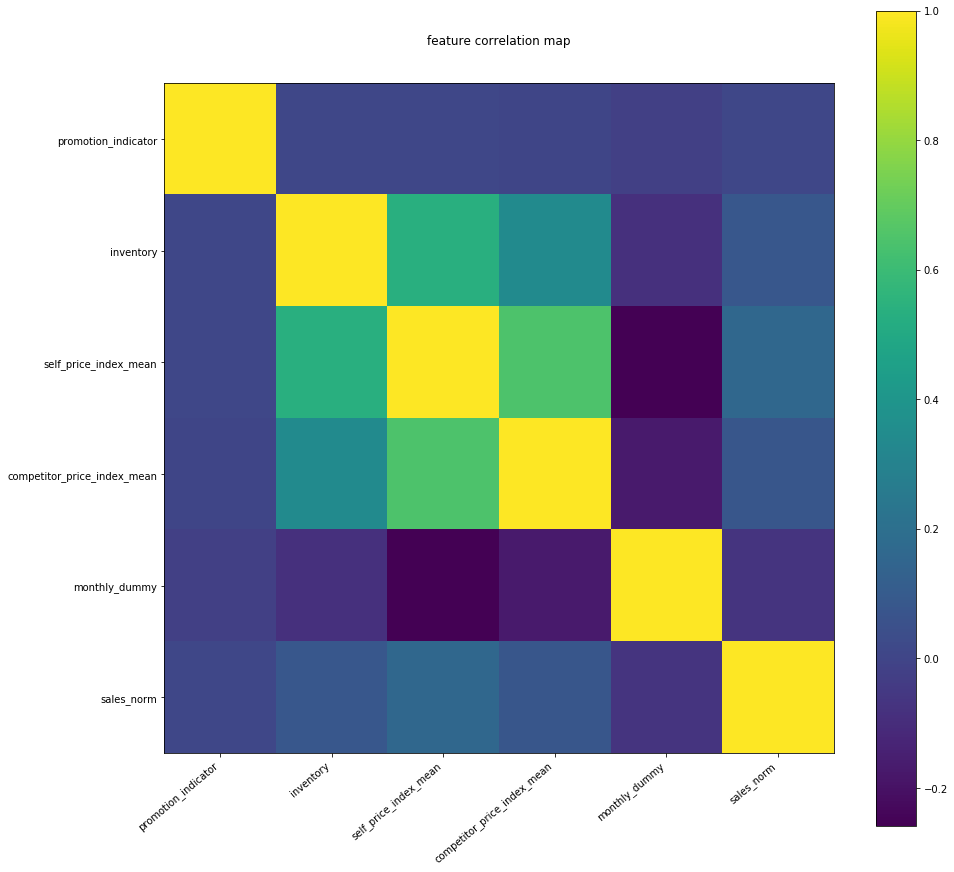

```python
from matplotlib import pyplot as plt
fig = plt.figure(figsize=(15,15))
ax = fig.add_subplot(111)
tmp = data_train.loc[:,['promotion_indicator', 'inventory', 'self_price_index_mean', 'competitor_price_index_mean', 'monthly_dummy', 'sales_norm']]
cax = ax.matshow(tmp.corr())
fig.colorbar(cax)
ax.set_xticks(np.arange(tmp.shape[1]))
ax.xaxis.set_ticklabels(tmp.columns, rotation=40, ha='right')
ax.xaxis.set_ticks_position('bottom')
ax.set_yticks(np.arange(tmp.shape[1]))
ax.yaxis.set_ticklabels(tmp.columns)
ax.set_title('feature correlation map')
```

Now the highest correlation is only less than 0.9. Let's keep all the features for now.

Since we are concered about promotional item, in the following line of code, we can see that we have 48 promotional entries in training data and 35 in testing data.

Active promotional items in Train vs in Test

```python
(data_train.promotion_indicator>0).sum(), (data_test.promotion_indicator>0).sum()
```

```
(48, 35)
```

### Modeling

#### Generalized linear model

Target (sales_norm) histogram.

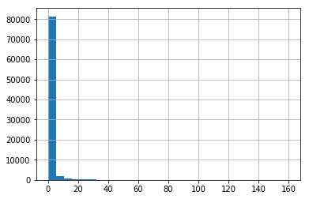

```python
data_sales_weekly.sales_norm.hist(bins=30)
```

Find $\boldsymbol{\Theta}$ that minimizes the loss function given by

$$ J = -log( f_{likelihood}(\boldsymbol{\boldsymbol{y}} | \boldsymbol{\Theta}) \cdot f_{prior}(\boldsymbol{w}) ) $$

$$ f_{likelihood}(\boldsymbol{y} | \boldsymbol{w}, \beta ) = \Pi_{i=1...N} \frac{\beta^{\alpha_i}}{\Gamma(\alpha_i)} y_i^{\alpha_i-1} e^{-\beta y_i} $$

where we assume independence among $y_i$ and N is the number of samples.

$$ f_{prior}(\boldsymbol{w}) = \Pi_{i=1...N} \frac{1}{\sqrt{2\pi \eta^2}} e^{-\frac{w_i^2}{2 \eta^2}} $$

where we assume Gaussian prior with 0 mean for $\boldsymbol{w}$ and a diagonal covariance matrix with the same entry $\eta$.

$\boldsymbol{y}$: observation vector,

$\boldsymbol{\Theta} = [\boldsymbol{w}, \beta]$,

$[\boldsymbol{\alpha}, \beta]$ for Gamma distribution so that $\mu=\frac{\boldsymbol{\alpha}}{\beta}$ and $\sigma^2=\frac{\boldsymbol{\alpha}}{\beta^2}$,

$\boldsymbol{\alpha}=e^{\boldsymbol{Xw}}$.

- Need point estimates for $\boldsymbol{\Theta}$ = find the *maximum a posteriori*, i.e. the MAP point in Bayesian statistics.
- Assume homescedasticity. We can give up the assumption by letting $\beta$ be a vector so that we can optimize it for each data point.
- We tried Laplace prior which is L1 regularization, or LASSO when Gaussian likelihood is used. It works similarly to Gaussian prior.
- Applying Gaussian prior with 0 mean is equivalent to using L2 regularization. We let the standard devaiation $\eta$ play the role of regularization parameter.
- Alternating direction optimization with L-BFGS-B, a quasi Newton method.
- Early stopping based on test error.
- Hyperparameters: inner iteration number for $\boldsymbol{w}$ and $\beta$ and the regularization parameter.
- Due to Gamma distribution, replace non-positive values to small positive constant.

From the following two lines we can check the range of sales_norm and we have a large number of zeros. Based on these, we can choose a proper small constant to replace the zeroes and negatives

```python
data_sales_weekly.sales_norm.max(), data_sales_weekly.sales_norm[data_sales_weekly.sales_norm>0].min(), data_sales_weekly.sales_norm.min()
```

```
(160.0, 0.31531015650041466, -0.07882753912510367)
```

```python
(data_sales_weekly.sales_norm==0).sum()
```

```
76290
```

```python
from scipy import optimize
import seaborn as sns
from scipy.special import gamma
from sklearn.metrics import mean_squared_error as mse
from sklearn.metrics import mean_absolute_error as mae
from sklearn.preprocessing import minmax_scale
from sklearn.preprocessing import scale
import math

def model(w, b, eta, X, y):
    a = np.exp(np.dot(X,w))
    likelihood = -np.log( (np.power(b,a)*np.power(y,a-1)*np.exp(-b*y))/gamma(a) )
    reg = eta*(np.dot(w,w)) # gaussian prior
#     reg = eta*(np.abs(w).sum()) # laplace prior
    loss = likelihood.sum() + reg
    return loss

def model_w(w, b, eta, X, y):
    return model(w, b, eta, X, y)

def model_b(b, w, eta, X, y):
    return model(w, b, eta, X, y)

eps = 0.01 # small constant to replace zero and negative sales_norm

# flag_dup = data_train['sales_norm'].duplicated()

X = data_train.loc[:, data_train.columns != 'sales_norm'].values
# X = minmax_scale(X)
X = scale(X)
X = np.hstack( (X,np.ones([X.shape[0],1]) ) )
X_test = data_test.loc[:, data_test.columns != 'sales_norm'].values
# X_test = minmax_scale(X_test)
X_test = scale(X_test)
X_test = np.hstack((X_test,np.ones([X_test.shape[0],1])))
y = data_train.loc[:, 'sales_norm'].replace(to_replace=0., value=eps).values
y_test = data_test.loc[:, 'sales_norm'].replace(to_replace=0., value=eps).values
y_test[y_test<0] = eps

np.random.seed(0)
w = 0.01*np.random.randn(X.shape[1])
b = 1e-3
eta = 0.
w_, b_, eta_ = np.copy(w), np.copy(b), np.copy(eta)
bounds_b = [(1e-4, None)]
bounds_eta = [(1e-16, None)]
max_iter = 500
niter = 1
tol = 1e-4
err_test = []
err_train = []
wait = 5
out_freq = 20
while 1:
    w_, f_w, dict_w = optimize.fmin_l_bfgs_b(model_w, w_, args=(b_, eta_, X, y), approx_grad=True, maxiter=1, pgtol=1e-12, factr=1e5)
    b_, f_b, dict_b = optimize.fmin_l_bfgs_b(model_b, b_, args=(w_, eta_, X, y), approx_grad=True, maxiter=1, pgtol=1e-12, factr=1e5, bounds=bounds_b)

    ypred_train = np.exp( np.dot( X, w_  ) )/b_
    ypred_test = np.exp(np.dot( X_test , w_))/b_
    err_train.append(mse(ypred_train, y))
    err_test.append(mse(ypred_test,y_test))
    if niter==1:
        w, b, eta = w_, b_, eta_
    elif (niter>1) and (err_test[-1]<np.min(err_test[:-1])):
        w, b, eta = w_, b_, eta_
    if niter%out_freq == 0:
        print('err_train: {}, err_test: {}'.format(err_train[-1], err_test[-1]))
    if niter > max_iter:
        print('Max iteration reached, break.')
        break
    if niter > 2*wait:
        if np.mean(err_test[-2*wait:-wait]) - np.mean(err_test[-wait::]) < 0:
            print('Waiting ends, meet tol, break.')
            break
        elif np.abs(np.mean(err_test[-2*wait:-wait]) - np.mean(err_test[-wait::]))<tol:
            print('err_test doesn\'t change, break.')
            break
    niter += 1
ypred_test = np.exp(np.dot( X_test, w))/b
ypred_train = np.exp(np.dot( X, w))/b
ypred_test_var = ypred_test/b
ypred_train_var = ypred_train/b
ypred = np.concatenate([ypred_train, ypred_test])
ypred_var = np.concatenate([ypred_train_var, ypred_test_var])
print('Training done in {} iterations: best err_train={}, best err_test={}'.format(niter, mse(ypred_train,y), mse(ypred_test,y_test)))
```

```
err_test doesn't change, break.
Training done in 11 iterations: best err_train=35.661352702478126, best err_test=8.91425263945485
```

Is Gamma distribution valid?

- qq-plot for qualitative check.
- Various tests for more quantative check.

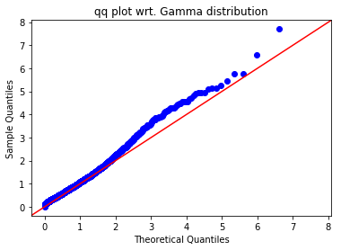

```python
from statsmodels.graphics.gofplots import qqplot
from scipy.stats import gamma
tmp = data_train.sales_norm.unique()*b
fig = qqplot(tmp, gamma, fit=True, line='45')
plt.title('qq plot wrt. Gamma distribution')
plt.show()
```

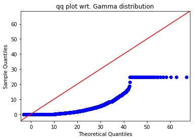

```python
from statsmodels.graphics.gofplots import qqplot
from scipy.stats import gamma
tmp = data_train.sales_norm*b
# (np.exp(np.dot(X,w)).mean()
fig = qqplot(tmp, gamma, distargs=(0.96,), loc=-3, scale=1/b, line='45')
plt.title('qq plot wrt. Gamma distribution')
plt.show()
```

Is the feature selection appropriate?

```python
base = 7.608753907717907
df_err = pd.DataFrame({'woCatGroup': [7.619282553266171], 'woPromoInd': [7.769830407880437], 'woInven': [7.626860469456199], 'woPriceInd': [7.632664347709986], \
          'woCompInd': [7.621210941130655], 'woMonth': [7.621007837325749], 'wOHEcompId': [7.765245371826289], 'wItemId': [7.999032576329604]})
df_err = df_err.applymap(lambda x: (x-base)/base*100)

cols = ['OHECatGroup', 'PromoInd', 'Inven', 'PriceInd', 'CompInd', 'Month', 'OHECompId', 'ItemId']
trace2 = go.Bar(
    x=cols,
    y=np.squeeze(np.hstack((df_err.loc[:, ['woCatGroup', 'woPromoInd', 'woInven', 'woPriceInd', 'woCompInd', 'woMonth']], np.zeros([1,2])))),
#     base = [-0.1383754, -2.116989, -0.2379701, -0.3142491, -0.1637198, -0.1610504 0, 0],
    marker=dict(
        color='rgba(55, 128, 191, 0.7)',
        line=dict(
            color='rgba(55, 128, 191, 1.0)',
        )
    ),
    name='kept feats'
)

trace1 = go.Bar(
    x=cols,
    y=np.squeeze(np.hstack( (np.zeros([1,6]), df_err.loc[:, ['wOHEcompId', 'wItemId']]))),
    base = [0, 0, 0, 0, 0, 0, -2.056729, -5.129338],
    marker=dict(
        color='rgba(219, 64, 82, 0.7)',
        line=dict(
            color='rgba(219, 64, 82, 1.0)',
        )
    ),
    name='discarded feats'
)

data = go.Data([trace1, trace2])
layout = go.Layout(xaxis={'autotick': True},
                     title='Feature selection / importance due to loss percentage change')
plotly.offline.iplot(go.Figure(data=data, layout=layout))
```

[interactive chart not shown]

```python
cols = data_train.columns.tolist()
cols.remove('sales_norm')
trace= go.Bar(x=cols, y=w[0:-1] )

data = go.Data([trace])
layout = go.Layout(xaxis={'autotick': True},
                     title='Coefficients of GLM')
plotly.offline.iplot(go.Figure(data=data, layout=layout))
```

[interactive chart not shown]

Now let's plot the results for all promotional products for each category.

```python
def data2plot(i_item_id):
    ind = data_sales_weekly['item_id']==i_item_id
    idata = data_sales_weekly.loc[ind, :]
    iypred = ypred[ind]
    iypred_var = ypred_var[ind]

    idata_promo_n = idata.loc[~idata['promotion_indicator'], :]
    iypred_promo_n = iypred[~idata['promotion_indicator']]
    iypred_var_promo_n = iypred_var[~idata['promotion_indicator']]
    idata_promo_y = idata.loc[idata['promotion_indicator'], :]
    iypred_promo_y = iypred[idata['promotion_indicator']]
    iypred_var_promo_y = iypred_var[idata['promotion_indicator']]
    return idata, idata_promo_n, idata_promo_y, iypred_promo_y, iypred_promo_n, iypred_var_promo_y, iypred_var_promo_n

item_sales_norm_mean = []
for i in catetory_id:
    ind = data_sales_weekly.loc[:, 'category_id']==i
    idata = data_sales_weekly.loc[ind, :]
    item_sales_norm_mean.append(idata.groupby('weekly_dummy')['sales_norm'].mean())

for icat in range(6):
    items = item_promo[icat]
    trace_list = []

    color = [['rgba(251,136,4,0.75)', 'rgba(73,45,13,0.75)'],
             ['rgba(84,149,223, 0.75)', 'rgb(33,97,171)'],
             ['rgba(136,80,234,0.75)',   'rgb(85,22,192)'],
             ['rgba(235,65,139,0.75)', 'rgb(180,19,89)']]
    cnt = 0
    for i_item_id in items:
        idata, idata_promo_n, idata_promo_y, iypred_y, iypred_n, iypred_var_y, iypred_var_n = data2plot(i_item_id)
        trace_idata_promo_n = go.Bar(x=idata_promo_n['yr_mo_mon'].map(lambda x: str(x)), y=idata_promo_n['sales_norm'],
                               marker=dict(color=color[cnt][0]),
                             name='item'+str(i_item_id) )
        trace_idata_promo_y = go.Bar(x=idata_promo_y['yr_mo_mon'].map(lambda x: str(x)), y=idata_promo_y['sales_norm'],
                               marker=dict(color=color[cnt][1]),
                               name='item'+str(i_item_id) + ' w/ promo')
        trace_ypred_promo_n = go.Scatter(x=idata_promo_n['yr_mo_mon'].map(lambda x: str(x)), y=iypred_n, error_y=dict(type='data', array=np.sqrt(iypred_var_n), visible=True),
                                         mode='markers',
                                         marker=dict(color=color[cnt][0]),
                                         name='pred item'+str(i_item_id) )
        trace_ypred_promo_y = go.Scatter(x=idata_promo_y['yr_mo_mon'].map(lambda x: str(x)), y=iypred_y, error_y=dict(type='data', array=np.sqrt(iypred_var_y), visible=True),
                                         mode='markers',
                                         marker=dict(color=color[cnt][1]),
                                         name='pred item'+str(i_item_id) + ' w/ promo')
        trace_list.extend([trace_idata_promo_y, trace_idata_promo_n, trace_ypred_promo_n, trace_ypred_promo_y])

        cnt += 1

    idata_mean = item_sales_norm_mean[icat]
    trace_mean = go.Scatter(x=idata['yr_mo_mon'].map(lambda x: str(x)), y=idata_mean,
                            mode='lines',
                            marker=dict(color='red'),
                            name='item mean')
    trace_list.append(trace_mean)

    data = go.Data(trace_list)
    layout = go.Layout(xaxis={'autotick': True},
                       barmode='stack',
                 showlegend=True,
                 title='Category'+ str(icat+1) + ' products w/ promo weekly normalized sales overlay with predictions')
    plotly.offline.iplot(go.Figure(data=data, layout=layout))
```

[interactive chart not shown]

Now let's calculate the lift and compare it with the observation.

```python
def lift_calc(ypred, ypred_var, model_name):
    item_promo = []
    item_promo_group = []
    catetory_id = data_sales_weekly.loc[:, 'category_id'].unique()
    for i in catetory_id:
        ind = data_sales_weekly.loc[:, 'category_id']==i
        idata = data_sales_weekly.loc[ind, :]

        item_sales_mean.append(idata.groupby('weekly_dummy')['sales_norm'].mean())
        iflag_promo = idata.groupby('item_id')['promotion_indicator'].sum()>0
        i_item_promo = iflag_promo.index[iflag_promo].values
        item_promo.append(i_item_promo)
        flag_tmp = np.zeros(idata.shape[0]) > 0
        for j in i_item_promo:
            flag_tmp = flag_tmp | (idata['item_id']==j)
        igroup = idata.loc[flag_tmp, 'group'].unique()
        if len(igroup) != len(i_item_promo):
            item_promo_group.append([igroup[0] for i in range(len(i_item_promo)) ])
        else:
            item_promo_group.append(igroup)

    ypred_sales = ypred * data_sales_weekly['sales_weekly_mean']
    if model_name!='lgb':
        ypred_sales_std = np.sqrt(ypred_var) * data_sales_weekly['sales_weekly_mean']
    else:
        ypred_sales_std = 0*data_sales_weekly['sales_weekly_mean']
    lift = []
    lift_pred = []
    lift_pred_std = []

    for i,j in zip(item_promo, item_promo_group):
        for m,n in zip(i,j):
            flag_group = data_sales_weekly['group']==n
            flag_item = data_sales_weekly['item_id']!=m
            flag_date = (data_sales_weekly['yr_mo_mon']>=datetime.datetime(year=2016,month=12,day=26)) & (data_sales_weekly['yr_mo_mon']<=datetime.datetime(year=2017,month=1,day=29))
            ind = flag_group & flag_item & flag_date
            idata = data_sales_weekly.loc[ind, 'sales']
            iypred_sales = ypred_sales[ind]
            iypred_sales_std = ypred_sales_std[ind]

            ind_promo = data_sales_weekly['promotion_indicator']
            idata_promo = data_sales_weekly.loc[ (~flag_item) & ind_promo, 'sales']
            iypred_sales_promo = ypred_sales[ (~flag_item) & ind_promo ]
            iypred_sales_std_promo = ypred_sales_std[ (~flag_item) & ind_promo ]

            flag_promo = ~data_sales_weekly['promotion_indicator']
            num_item_not_promo = (data_sales_weekly.loc[flag_date&flag_group&flag_promo, 'item_id'].unique() != m).sum()

            lift.append( idata_promo.sum() - idata.sum()/num_item_not_promo )
            lift_pred.append( iypred_sales_promo.sum() - iypred_sales.sum()/num_item_not_promo )
            lift_pred_std.append( iypred_sales_std_promo.sum() + iypred_sales_std.sum()/num_item_not_promo )

    item_promo_flat = []
    item_promo_group_flat = []
    for i,j in zip(item_promo,item_promo_group):
        item_promo_flat.extend([m for m in i])
        item_promo_group_flat.extend([n for n in j])

    if model_name != 'lgb':
        lift_df = pd.DataFrame( {'item_id': item_promo_flat, 'group': item_promo_group_flat, 'lift': lift, 'lift_pred': lift_pred, 'lift_pred_std':lift_pred_std} )
    else:
        lift_df = pd.DataFrame( {'item_id': item_promo_flat, 'group': item_promo_group_flat, 'lift': lift, 'lift_pred': lift_pred} )

    if len(data_sales_weekly.loc[data_sales_weekly.group==79, 'item_id'].unique()) == 1:
        print('Item {} is by itself in group 79, thus lift N/A.'.format(data_sales_weekly.loc[data_sales_weekly.group==79, 'item_id'].unique()))

    return lift_df
```

```python
lift_df_gamma = lift_calc(ypred, ypred_var, 'gamma')
lift_df_gamma
```

```
Item [512464637] is by itself in group 79, thus lift N/A.
```

|  | group | item_id | lift | lift_pred | lift_pred_std |
| --- | --- | --- | --- | --- | --- |
| 0 | 48 | 512317770 | 33.342500 | 738.391161 | 4972.834549 |
| 1 | 35 | 512319171 | 699.080000 | 576.922706 | 2020.969637 |
| 2 | 40 | 512319983 | -186.067143 | -471.325300 | 1377.933299 |
| 3 | 44 | 515375113 | 168.244000 | 307.004088 | 1703.240638 |
| 4 | 27 | 512018493 | 956.648000 | -30.767682 | 841.096781 |
| 5 | 27 | 513103198 | 335.988000 | 287.278116 | 1482.775865 |
| 6 | 79 | 512464637 | NaN | NaN | NaN |
| 7 | 91 | 514002190 | 902.630000 | 13.389290 | 492.467686 |
| 8 | 60 | 512319146 | 899.110000 | 428.667177 | 2708.726815 |
| 9 | 59 | 514002186 | 710.888000 | 89.666841 | 955.186790 |
| 10 | 4 | 512317789 | 1719.478000 | 1797.875781 | 6212.358255 |
| 11 | 9 | 514002189 | 0.000000 | 4.161016 | 62.949911 |

```python
trace = go.Scatter(x=lift_df_gamma.item_id.map(lambda x: 'item_'+str(x)), y=lift_df_gamma.lift,
                                         mode='markers and lines',
                                         name='lift')

trace_pred = go.Scatter(x=lift_df_gamma.item_id.map(lambda x: 'item_'+str(x)), y=lift_df_gamma.lift_pred, error_y=dict(type='data', array=lift_df_gamma.lift_pred_std, visible=True),
                                         mode='markers and lines',
                                        marker=dict(symbol='x'),
                                         name='lift_pred')

data = go.Data([trace, trace_pred])
layout = go.Layout(xaxis={'autotick': True},
                 showlegend=True,
                 title='Lift comparison for GLM')
plotly.offline.iplot(go.Figure(data=data, layout=layout))
```

[interactive chart not shown]

```python
def cat_plot(m, n):
    ypred_sales = ypred * data_sales_weekly['sales_weekly_mean']
    ypred_sales_std = np.sqrt(ypred_var) * data_sales_weekly['sales_weekly_mean']

    flag_group = data_sales_weekly['group']==n
    flag_item = data_sales_weekly['item_id']!=m
    flag_date = (data_sales_weekly['yr_mo_mon']>=datetime.datetime(year=2016,month=12,day=26)) & (data_sales_weekly['yr_mo_mon']<=datetime.datetime(year=2017,month=1,day=29))
    ind = flag_group & flag_item
    idata = data_sales_weekly.loc[ind, ['sales', 'yr_mo_mon']]
    iypred_sales = ypred_sales[ind]
    iypred_sales_std = ypred_sales_std[ind]

    ind_promo = data_sales_weekly['item_id']==m
    idata_promo = data_sales_weekly.loc[ind_promo, ['sales', 'yr_mo_mon']]
    iypred_sales_promo = ypred_sales[ind_promo]
    iypred_sales_std_promo = ypred_sales_std[ind_promo]

    flag_promo = ~data_sales_weekly['promotion_indicator']
    num_item_not_promo = (data_sales_weekly.loc[flag_group&flag_promo, 'item_id'].unique() != m).sum()

    sales_promoY_inPromoPeriod = idata_promo.loc[flag_date, :]
    sales_promoY_pred_inPromoPeriod = iypred_sales_promo[flag_date]
    sales_promoN_inPromoPeriod = idata.loc[flag_date, :].groupby('yr_mo_mon').sum()/num_item_not_promo
    sales_promoN_pred_inPromoPeriod = iypred_sales[flag_date]

    sales_promoY_outPromoPeriod = idata_promo.loc[~flag_date, :]
    sales_promoY_pred_outPromoPeriod = iypred_sales_promo[~flag_date]
    sales_promoN_outPromoPeriod = idata.loc[~flag_date, :].groupby('yr_mo_mon').sum()/num_item_not_promo
    sales_promoN_pred_outPromoPeriod = iypred_sales[~flag_date]

    date_inPromoPeriod = idata_promo.loc[flag_date, 'yr_mo_mon'].map(lambda x: str(x))
    date_outPromoPeriod = idata_promo.loc[~flag_date, 'yr_mo_mon'].map(lambda x: str(x))

    color = [['rgba(251,136,4,0.75)', 'rgba(73,45,13,0.75)'],
             ['rgba(84,149,223, 0.75)', 'rgb(33,97,171)'],
             ['rgba(136,80,234,0.75)',   'rgb(85,22,192)'],
             ['rgba(235,65,139,0.75)', 'rgb(180,19,89)']]

    # in promotion period
    trace_promoY_inPromoPeriod = go.Scatter(x=date_inPromoPeriod, y=sales_promoY_inPromoPeriod['sales'],
                            mode='markers',
                            marker=dict(color=color[0][0]),
                            name='item_promo_inPromo')

    trace_promoY_pred_inPromoPeriod = go.Scatter(x=date_inPromoPeriod, y=sales_promoY_pred_inPromoPeriod,
                            mode='markers',
                            marker=dict(color=color[1][0], symbol='x', size=10),
                            name='item_promo_pred_inPromo')

    trace_promoN_inPromoPeriod = go.Scatter(x=date_inPromoPeriod, y=sales_promoN_inPromoPeriod['sales'],
                            mode='markers',
                            marker=dict(color=color[2][0]),
                            name='item_others_avg_inPromo')

    trace_promoN_pred_inPromoPeriod = go.Scatter(x=date_inPromoPeriod, y=sales_promoN_pred_inPromoPeriod,
                            mode='markers',
                            marker=dict(color=color[3][0], symbol='x', size=10),
                            name='item_others_avg_pred_inPromo')
    # out of promotion period
    trace_promoY_outPromoPeriod = go.Scatter(x=date_outPromoPeriod, y=sales_promoY_outPromoPeriod['sales'],
                            mode='markers',
                            marker=dict(color=color[0][1]),
                            name='item_promo')

    trace_promoY_pred_outPromoPeriod = go.Scatter(x=date_outPromoPeriod, y=sales_promoY_pred_outPromoPeriod,
                            mode='markers',
                            marker=dict(color=color[1][1], symbol='x', size=10),
                            name='item_promo_pred')

    trace_promoN_outPromoPeriod = go.Scatter(x=date_outPromoPeriod, y=sales_promoN_outPromoPeriod['sales'],
                            mode='markers',
                            marker=dict(color=color[2][1]),
                            name='item_others_avg')

    trace_promoN_pred_outPromoPeriod = go.Scatter(x=date_outPromoPeriod, y=sales_promoN_pred_outPromoPeriod,
                            mode='markers',
                            marker=dict(color=color[3][1], symbol='x', size=10),
                            name='item_others_avg_pred')

    trace_list = [trace_promoY_inPromoPeriod, trace_promoY_pred_inPromoPeriod, trace_promoN_inPromoPeriod, trace_promoN_pred_inPromoPeriod,
                  trace_promoY_outPromoPeriod, trace_promoY_pred_outPromoPeriod, trace_promoN_outPromoPeriod, trace_promoN_pred_outPromoPeriod]

    data = go.Data(trace_list)
    layout = go.Layout(xaxis={'autotick': True},
                       barmode='stack',
                 showlegend=True,
                 title='Group_'+ str(n) + ' item_' + str(m) + ' weekly sales overlay with predictions')
    plotly.offline.iplot(go.Figure(data=data, layout=layout))
```

Take a more detailed look at the two components of lift calc.

```python
item_id = 512319146
group_id = 60
cat_plot(item_id, group_id)
```

[interactive chart not shown]

### Modeling

#### Tree-based models

- Gamma regression

```python
import lightgbm as lgb

eps = 0.01
X = data_train.loc[:, data_train.columns != 'sales_norm']
X_test = data_test.loc[:, data_test.columns != 'sales_norm']
y = data_train.loc[:, 'sales_norm'].replace(to_replace=0., value=eps)
y_test = data_test.loc[:, 'sales_norm'].replace(to_replace=0., value=eps)
y_test[y_test<0] = eps

cat_col_ind = []
cat_col = ['item_id', 'weekly_dummy', 'price_competitor_min_id', 'promotion_indicator', 'group']
for i in range(len(X.columns)):
    if X.columns[i] in cat_col:
        cat_col_ind.append(i)

lgb_train = lgb.Dataset(X, y.values)
lgb_eval = lgb.Dataset(X_test, y_test.values, reference=lgb_train)

params = {
    'task': 'train',
    'boosting_type': 'gbdt',
    'objective': 'gamma',
    'metric': {'l2'},
    'num_leaves': 11,
    'max_depth': -1,
    'learning_rate': 0.04,
    'feature_fraction': 0.9,
    'bagging_fraction': 0.85,
    'bagging_freq': 7,
    'nthread': 16,
#     'categorical_feature': cat_col_ind,
    'verbose': -1
}

# train
gbm = lgb.train(params,
                lgb_train,
                num_boost_round=500,
                valid_sets=lgb_eval,
                early_stopping_rounds=20,
                verbose_eval=False)

ypred_test = gbm.predict(X_test, num_iteration=gbm.best_iteration)
ypred_train = gbm.predict(X, num_iteration=gbm.best_iteration)
ypred = np.concatenate([ypred_train, ypred_test])
print('Training done in {} iterations: best err_train={}, best err_test={}'.format(gbm.best_iteration, mse(ypred_train,y), mse(ypred_test,y_test)))
```

```
Training done in 60 iterations: best err_train=33.78595885943256, best err_test=8.124661872979763
```

Let's examine the feature importance. The default feature importance score in LGBM is based on the times the feature is used for splitting in the model.

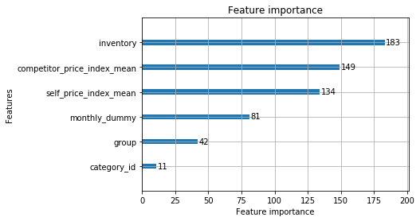

```python
lgb.plot_importance(gbm)
```

Similarly, let's also compute the lift table.

```python
lift_df_lgb_gamma = lift_calc(ypred, None, 'lgb')
lift_df_lgb_gamma
```

```
Item [512464637] is by itself in group 79, thus lift N/A.
```

|  | group | item_id | lift | lift_pred |
| --- | --- | --- | --- | --- |
| 0 | 48 | 512317770 | 33.342500 | 1238.011014 |
| 1 | 35 | 512319171 | 699.080000 | -63.439643 |
| 2 | 40 | 512319983 | -186.067143 | -368.757865 |
| 3 | 44 | 515375113 | 168.244000 | 365.711113 |
| 4 | 27 | 512018493 | 956.648000 | -205.128843 |
| 5 | 27 | 513103198 | 335.988000 | 291.259133 |
| 6 | 79 | 512464637 | NaN | NaN |
| 7 | 91 | 514002190 | 902.630000 | -105.271064 |
| 8 | 60 | 512319146 | 899.110000 | 1028.258204 |
| 9 | 59 | 514002186 | 710.888000 | 430.145647 |
| 10 | 4 | 512317789 | 1719.478000 | 2466.511732 |
| 11 | 9 | 514002189 | 0.000000 | -9.219966 |

- Tweedie regression

```python
import lightgbm as lgb

X = data_train.loc[:, data_train.columns != 'sales_norm']
X_test = data_test.loc[:, data_test.columns != 'sales_norm']
y = data_train.loc[:, 'sales_norm']
y_test = data_test.loc[:, 'sales_norm']

cat_col_ind = []
cat_col = ['item_id', 'weekly_dummy', 'price_competitor_min_id', 'promotion_indicator', 'group']
for i in range(len(X.columns)):
    if X.columns[i] in cat_col:
        cat_col_ind.append(i)

lgb_train = lgb.Dataset(X, y.values)
lgb_eval = lgb.Dataset(X_test, y_test.values, reference=lgb_train)

params = {
    'task': 'train',
    'boosting_type': 'gbdt',
    'objective': 'tweedie',
    'metric': {'l2'},
    'num_leaves': 10,
    'max_depth': -1,
    'learning_rate': 0.05,
    'feature_fraction': 0.9,
    'bagging_fraction': 0.85,
    'bagging_freq': 3,
    'nthread': 16,
#     'categorical_feature': cat_col_ind,
    'verbose': -1
}

# train
gbm = lgb.train(params,
                lgb_train,
                num_boost_round=500,
                valid_sets=lgb_eval,
                early_stopping_rounds=20,
                verbose_eval=False)

ypred_test = gbm.predict(X_test, num_iteration=gbm.best_iteration)
ypred_train = gbm.predict(X, num_iteration=gbm.best_iteration)
ypred = np.concatenate([ypred_train, ypred_test])
print('Training done in {} iterations: best err_train={}, best err_test={}'.format(gbm.best_iteration, mse(ypred_train,y), mse(ypred_test,y_test)))
```

```
Training done in 219 iterations: best err_train=30.76339459202544, best err_test=7.3927334169360925
```

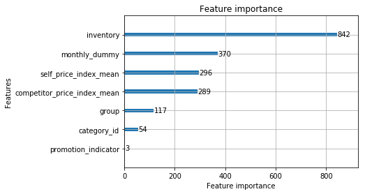

```python
lgb.plot_importance(gbm)
```

```python
lift_df_lgb_tweedie = lift_calc(ypred, None, 'lgb')
lift_df_lgb_tweedie
```

```
Item [512464637] is by itself in group 79, thus lift N/A.
```

|  | group | item_id | lift | lift_pred |
| --- | --- | --- | --- | --- |
| 0 | 48 | 512317770 | 33.342500 | -86.274656 |
| 1 | 35 | 512319171 | 699.080000 | -64.580939 |
| 2 | 40 | 512319983 | -186.067143 | -261.491720 |
| 3 | 44 | 515375113 | 168.244000 | -24.474249 |
| 4 | 27 | 512018493 | 956.648000 | -187.276069 |
| 5 | 27 | 513103198 | 335.988000 | 292.196376 |
| 6 | 79 | 512464637 | NaN | NaN |
| 7 | 91 | 514002190 | 902.630000 | -92.184542 |
| 8 | 60 | 512319146 | 899.110000 | 702.123395 |
| 9 | 59 | 514002186 | 710.888000 | 823.554499 |
| 10 | 4 | 512317789 | 1719.478000 | 3605.694646 |
| 11 | 9 | 514002189 | 0.000000 | -8.638965 |

- Poisson regression

```python
import lightgbm as lgb

X = data_train.loc[:, data_train.columns != 'sales_norm']
X_test = data_test.loc[:, data_test.columns != 'sales_norm']
y = data_train.loc[:, 'sales_norm']
y_test = data_test.loc[:, 'sales_norm']

cat_col_ind = []
cat_col = ['item_id', 'weekly_dummy', 'price_competitor_min_id', 'promotion_indicator', 'group']
for i in range(len(X.columns)):
    if X.columns[i] in cat_col:
        cat_col_ind.append(i)

lgb_train = lgb.Dataset(X, y.values)
lgb_eval = lgb.Dataset(X_test, y_test.values, reference=lgb_train)

params = {
    'task': 'train',
    'boosting_type': 'gbdt',
    'objective': 'poisson',
    'metric': {'l2'},
    'num_leaves': 10,
    'max_depth': -1,
    'learning_rate': 0.05,
    'feature_fraction': 0.75,
    'bagging_fraction': 0.85,
    'bagging_freq': 3,
    'nthread': 16,
#     'categorical_feature': cat_col_ind,
    'verbose': -1
}

# train
gbm = lgb.train(params,
                lgb_train,
                num_boost_round=500,
                valid_sets=lgb_eval,
                early_stopping_rounds=20,
                verbose_eval=False)

ypred_test = gbm.predict(X_test, num_iteration=gbm.best_iteration)
ypred_train = gbm.predict(X, num_iteration=gbm.best_iteration)
ypred = np.concatenate([ypred_train, ypred_test])
print('Training done in {} iterations: best err_train={}, best err_test={}'.format(gbm.best_iteration, mse(ypred_train,y), mse(ypred_test,y_test)))
```

```
Training done in 167 iterations: best err_train=29.98553405031738, best err_test=7.241316122754773
```

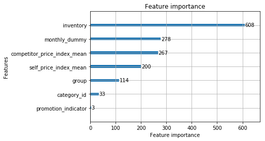

```python
lgb.plot_importance(gbm)
```

```python
lift_df_lgb_poisson = lift_calc(ypred, None, 'lgb')
lift_df_lgb_poisson
```

```
Item [512464637] is by itself in group 79, thus lift N/A.
```

|  | group | item_id | lift | lift_pred |
| --- | --- | --- | --- | --- |
| 0 | 48 | 512317770 | 33.342500 | -39.231711 |
| 1 | 35 | 512319171 | 699.080000 | -67.087725 |
| 2 | 40 | 512319983 | -186.067143 | -352.627606 |
| 3 | 44 | 515375113 | 168.244000 | 105.127114 |
| 4 | 27 | 512018493 | 956.648000 | -195.035731 |
| 5 | 27 | 513103198 | 335.988000 | 319.490699 |
| 6 | 79 | 512464637 | NaN | NaN |
| 7 | 91 | 514002190 | 902.630000 | -99.201747 |
| 8 | 60 | 512319146 | 899.110000 | 831.659747 |
| 9 | 59 | 514002186 | 710.888000 | 834.730326 |
| 10 | 4 | 512317789 | 1719.478000 | 3938.985225 |
| 11 | 9 | 514002189 | 0.000000 | -10.402025 |

```python
trace = go.Scatter(x=lift_df_gamma.item_id.map(lambda x: 'item_'+str(x)), y=lift_df_gamma.lift,
                                         mode='markers and lines',
                                         name='lift')

trace_lgb_gamma = go.Scatter(x=lift_df_lgb_gamma.item_id.map(lambda x: 'item_'+str(x)), y=lift_df_lgb_gamma.lift_pred,
                                         mode='markers and lines',
                                        marker=dict(symbol='x'),
                                         name='lift_pred_gamma')

trace_lgb_tweedie = go.Scatter(x=lift_df_lgb_tweedie.item_id.map(lambda x: 'item_'+str(x)), y=lift_df_lgb_tweedie.lift_pred,
                                         mode='markers and lines',
                                        marker=dict(symbol='x'),
                                         name='lift_pred_tweedie')

trace_lgb_poisson = go.Scatter(x=lift_df_lgb_poisson.item_id.map(lambda x: 'item_'+str(x)), y=lift_df_lgb_poisson.lift_pred,
                                         mode='markers and lines',
                                        marker=dict(symbol='x'),
                                         name='lift_pred_poisson')

data = go.Data([trace, trace_lgb_gamma, trace_lgb_tweedie, trace_lgb_poisson])
layout = go.Layout(xaxis={'autotick': True},
                 showlegend=True,
                 title='Lift comparison for LGBM')
plotly.offline.iplot(go.Figure(data=data, layout=layout))
```

[interactive chart not shown]

### Summary

```python
lift_df = pd.DataFrame( { 'item_id':lift_df_gamma.item_id,
                          'group': lift_df_gamma.group,
                          'lift_truth': lift_df_gamma.lift,
                          'lift_pred_gamma': lift_df_gamma.lift_pred,
                          'lift_pred_gamma_std': lift_df_gamma.lift_pred_std,
                          'lift_pred_lgb_gamma': lift_df_lgb_gamma.lift_pred,
                          'lift_pred_lgb_tweedie': lift_df_lgb_tweedie.lift_pred,
                          'lift_pred_lgb_poisson': lift_df_lgb_poisson.lift_pred} )
lift_df
```

|  | group | item_id | lift_pred_gamma | lift_pred_gamma_std | lift_pred_lgb_gamma | lift_pred_lgb_poisson | lift_pred_lgb_tweedie | lift_truth |
| --- | --- | --- | --- | --- | --- | --- | --- | --- |
| 0 | 48 | 512317770 | 738.391161 | 4972.834549 | 1238.011014 | -39.231711 | -86.274656 | 33.342500 |
| 1 | 35 | 512319171 | 576.922706 | 2020.969637 | -63.439643 | -67.087725 | -64.580939 | 699.080000 |
| 2 | 40 | 512319983 | -471.325300 | 1377.933299 | -368.757865 | -352.627606 | -261.491720 | -186.067143 |
| 3 | 44 | 515375113 | 307.004088 | 1703.240638 | 365.711113 | 105.127114 | -24.474249 | 168.244000 |
| 4 | 27 | 512018493 | -30.767682 | 841.096781 | -205.128843 | -195.035731 | -187.276069 | 956.648000 |
| 5 | 27 | 513103198 | 287.278116 | 1482.775865 | 291.259133 | 319.490699 | 292.196376 | 335.988000 |
| 6 | 79 | 512464637 | NaN | NaN | NaN | NaN | NaN | NaN |
| 7 | 91 | 514002190 | 13.389290 | 492.467686 | -105.271064 | -99.201747 | -92.184542 | 902.630000 |
| 8 | 60 | 512319146 | 428.667177 | 2708.726815 | 1028.258204 | 831.659747 | 702.123395 | 899.110000 |
| 9 | 59 | 514002186 | 89.666841 | 955.186790 | 430.145647 | 834.730326 | 823.554499 | 710.888000 |
| 10 | 4 | 512317789 | 1797.875781 | 6212.358255 | 2466.511732 | 3938.985225 | 3605.694646 | 1719.478000 |
| 11 | 9 | 514002189 | 4.161016 | 62.949911 | -9.219966 | -10.402025 | -8.638965 | 0.000000 |

```python
lift_df_err = lift_df.apply(lambda x: np.abs((x-lift_df.lift_truth)/lift_df.lift_truth)*100, axis=0).loc[:, ['lift_pred_gamma', 'lift_pred_lgb_gamma', 'lift_pred_lgb_poisson', 'lift_pred_lgb_tweedie']]
lift_df_err = lift_df_err.loc[~lift_df_err.lift_pred_gamma.isin([np.nan, np.inf]), :]

trace1 = go.Box(y=lift_df_err.lift_pred_gamma, name='lift_glm_gamma')
trace2 = go.Box(y=lift_df_err.lift_pred_lgb_gamma, name='lift_lgb_gamma')
trace3 = go.Box(y=lift_df_err.lift_pred_lgb_poisson, name='lift_lgb_poisson')
trace4 = go.Box(y=lift_df_err.lift_pred_lgb_tweedie, name='lift_lgb_tweedie')

data = go.Data([trace1, trace2, trace3, trace4])
layout = go.Layout(xaxis={'autotick': True},
                 showlegend=True,
                 title='Lift absolute percent error summary')
plotly.offline.iplot(go.Figure(data=data, layout=layout))
```

[interactive chart not shown]

Potential improvements for modeling:

- A mixture model with different distributions or even constants (e.g. zero-inflated Gamma)
- Hierarchical Bayesian: let parameters be independent for difference categories / groups but from the same distribution.
- More feature engineering with feature interactions: exhaustive or genetic algorithms.
- Not a good practice to use the test data as validation data. Better validation strategy, such as forward chaining for data with temporal pattern.
- Deep learning, e.g. project features to a low-dimensional latent space with Auto-encoders; cat2vec.
- Model ensembling / stacking, e.g.:

> 1111111111 Truth

> 1111111100 Model1, 80% accuracy

> 0111011101 Model2, 70% accuracy

> 1000101111 Model3, 60% accuracy

> 1111111101 Ensemble with major vote, 90% accuracy